# Charge point utilisation forecast

This notebook contains a simple version of a machine learning (ML) model that uses traffic data to estimate KWh consumption at charge point. The data used was synthetically generated.

```python
import pandas as pd
from sklearn.linear_model import LinearRegression, Ridge, Lasso, BayesianRidge, SGDRegressor
from sklearn.neural_network import MLPRegressor
from sklearn.preprocessing import PolynomialFeatures
from sklearn.ensemble import RandomForestRegressor
from sklearn.feature_selection import RFECV, SelectKBest, mutual_info_regression
from sklearn.svm import SVR
import warnings
from sklearn.compose import ColumnTransformer
from sklearn.pipeline import Pipeline
from sklearn.model_selection import GridSearchCV, StratifiedShuffleSplit, cross_validate
from sklearn.preprocessing import StandardScaler
from sklearn.metrics import mean_absolute_percentage_error
from tqdm import tqdm
import seaborn as sns
import matplotlib.pyplot as plt
from scipy import stats
import numpy as np
warnings.filterwarnings('ignore')
```

## Introduction

The cell below imports the synthetic data. This data set is made by the following columns

- kWh which represents the energy consumption;
- total traffic; and
- segment X which represent traffic segments.

  A traffic segment is a portion of the traffic that is determined by certain characteristics. For example, segment 1 could represent trips that have travelled for at least 100 km before they traversed the charge point vicinity, have another 100 km to reach destination, are more than 80 km away from their residence and ara travelling to a non-work, non-home location.

  An important part of the ML exercise is determining what features (segments) contain more information about the charge point utilisation which is performed further below via two mehanism, mutual information regression and recursive feature elimination.

```python
# Overall data
df_initial = pd.read_csv(r'..\data\in\Utilisation_with_Traffic.csv')
df_initial.columns = [x.lower() for x in df_initial.columns]
for n in range(1, 56):
    df_initial[f'segment {n}'] = df_initial[f'segment {n}'].apply(lambda x: x.replace(',', '')).astype(int)
df_initial['total traffic'] = df_initial['total traffic'].apply(
    lambda x: x.replace(',', '')).astype(int)
df_initial.set_index('site_id', inplace=True)
display(df_initial)
```

| site_id | kwh | total traffic | segment 1 | segment 2 | segment 3 | segment 4 | segment 5 | segment 6 | segment 7 | segment 8 | ... | segment 46 | segment 47 | segment 48 | segment 49 | segment 50 | segment 51 | segment 52 | segment 53 | segment 54 | segment 55 |
| --- | --- | --- | --- | --- | --- | --- | --- | --- | --- | --- | --- | --- | --- | --- | --- | --- | --- | --- | --- | --- | --- |
| 1 | 1367 | 20289 | 619 | 2602 | 306 | 2276 | 148 | 52 | 3958 | 139 | ... | 2510 | 2539 | 6804 | 1779 | 2386 | 979 | 4201 | 3229 | 990 | 2395 |
| 13 | 3756 | 40867 | 11372 | 2316 | 1578 | 3763 | 1176 | 3094 | 1253 | 1921 | ... | 3898 | 645 | 2508 | 336 | 10753 | 3606 | 7131 | 7791 | 10844 | 108 |
| 26 | 1303 | 25698 | 2005 | 381 | 935 | 2488 | 3520 | 605 | 646 | 2188 | ... | 4602 | 1140 | 5000 | 2093 | 11001 | 1840 | 1250 | 766 | 954 | 1033 |
| 38 | 2664 | 40951 | 4515 | 2096 | 2332 | 6376 | 1924 | 4110 | 2978 | 1902 | ... | 1610 | 1445 | 320 | 353 | 9111 | 1348 | 2701 | 4043 | 5063 | 3921 |
| 64 | 3028 | 69489 | 4331 | 50139 | 10798 | 3031 | 1070 | 1443 | 1036 | 5970 | ... | 1447 | 3108 | 2610 | 320 | 5579 | 4573 | 10066 | 1243 | 16241 | 1521 |
| ... | ... | ... | ... | ... | ... | ... | ... | ... | ... | ... | ... | ... | ... | ... | ... | ... | ... | ... | ... | ... | ... |
| 72 | 9864 | 488600 | 29988 | 34547 | 28821 | 29837 | 433 | 1932 | 4328 | 3046 | ... | 3493 | 341 | 134 | 338 | 40455 | 4947 | 18914 | 61046 | 100819 | 29027 |
| 85 | 5698 | 190577 | 16368 | 11340 | 632 | 5767 | 1807 | 1586 | 5237 | 1043 | ... | 2353 | 7490 | 954 | 362 | 7701 | 4886 | 15169 | 273 | 17736 | 4700 |
| 39 | 9032 | 106970 | 26728 | 829 | 69088 | 21149 | 1496 | 406 | 382 | 1929 | ... | 2690 | 1049 | 829 | 998 | 18222 | 4645 | 17384 | 20136 | 28589 | 7300 |
| 86 | 4793 | 55895 | 8609 | 250 | 9586 | 4951 | 2360 | 6319 | 1234 | 503 | ... | 6713 | 1341 | 5933 | 2865 | 967 | 8101 | 11711 | 1828 | 2406 | 6446 |
| 79 | 10127 | 250157 | 3031 | 7378 | 66614 | 31139 | 453 | 1256 | 813 | 1374 | ... | 6887 | 4127 | 1311 | 510 | 22356 | 14453 | 11332 | 1823 | 18833 | 3924 |

88 rows × 57 columns

## Train-Test Split

Before we look at the data any further let's split it between a test and a training set. The size of the data sample is not big and we want both the test and the train splits to be as representative as possible of the whole population of charge points. To achive this we introduce a new column indicating what quartile the site belongs to and use stratified sampling based on that.

```python
df_initial['quartiles'] = pd.qcut(df_initial['kwh'], [0, .25, .5, .75, 1.])
split = StratifiedShuffleSplit(n_splits=1, test_size=0.2, random_state=50)
for train_index, test_index in tqdm(split.split(df_initial, df_initial["quartiles"])):
 strat_train_set = df_initial.loc[df_initial.index[train_index]]
 strat_test_set = df_initial.loc[df_initial.index[test_index]]
#
strat_train_set['quartiles'].value_counts(normalize=True)
```

```
1it [00:00, 83.56it/s]
```

```
(3591.75, 5472.5]      0.257143
(5472.5, 8196.75]      0.257143
(1302.999, 3591.75]    0.242857
(8196.75, 13349.0]     0.242857
Name: quartiles, dtype: float64
```

## Feature engineering

A basic feature engineering protocol that should almost alwyas be applied is standard scaling. This process ensures that the scale of the feature has no impact on its relevancy.

```python
charge_points = strat_train_set.copy()
corr_matrix = charge_points.corr()
corr_matrix["kwh"].sort_values(ascending=False)
#
charge_points = strat_train_set.drop(columns=['kwh', 'quartiles'])
charge_points_labels = strat_train_set['kwh'].copy()
charge_points_quartiles = strat_train_set['quartiles'].copy()
#
test_cp = strat_test_set.drop(columns=['kwh', 'quartiles'])
test_cp_labels = strat_test_set['kwh'].copy()
test_cp_quartiles = strat_test_set['quartiles'].copy()
#
std_scaler = StandardScaler()
X = std_scaler.fit_transform(charge_points)
```

As mentioned above feature selection is an important part of this process as it helps reduce the number of features used minimising the chances of overfitting or finding an arbitrary relationship between features and target that will not be present in the test data or the 'real world'.

To achieve this a mutual information regression analysis was performed to select the 15th most informative variables available.

```python
k = 15
# define feature selection
fs = SelectKBest(k=k, score_func=mutual_info_regression)
# apply feature selection
fs = fs.fit(X, charge_points_labels)
s_cols = fs.get_feature_names_out(input_features=charge_points.columns)
X_r = fs.transform(X)
```

Both the standard scaler and the mutual information analysis were inserted into a pipeline for later use in the training data set.

```python
features_pipeline = Pipeline([('std_scaler', std_scaler), ('selectkbest', fs)])
```

## Model's short list

Now that the features have been selected and standarised we can train a number of regression algorithms and build a short list with the most promising ones.

The cell belows trains the following models: Ridge, Lasso, Linear, Polynomial, Bayesian Ridge, Random Forest, Support Vector Machine, Stochastic Gradient Descent, and a Multi-layer Perceptron.

```python
poly = Pipeline([('poly', PolynomialFeatures(degree=2)),
                  ('linear', LinearRegression(fit_intercept=False))])

long_list_models = {'ridge': Ridge(), 'lasso': Lasso(), 'lr': LinearRegression(),
                    'poly': poly, 'br': BayesianRidge(),  'rfr': RandomForestRegressor(),
                    'svr': SVR(), 'sgdr': SGDRegressor(), 'nn': MLPRegressor()}
ll_models_scores = {}
for m in tqdm(long_list_models):
    ll_models_scores[m] = cross_validate(long_list_models[m], X_r, charge_points_labels,
                                         scoring='neg_mean_absolute_percentage_error', cv=5)

temp_dict = {}
for m in ll_models_scores:
    temp_dict[m] = ll_models_scores[m]['test_score']
```

The result of the preliminary training shows that Stochastic Gradient Descent is the best performer with an average of 20% absolute percentage error in its predictions.

The complete list of models with performance is shown below. The best 4 performing models were shortlisted for fine-tunning.

```python
display(pd.DataFrame.from_dict(temp_dict).mean().sort_values())
short_list = pd.DataFrame.from_dict(temp_dict).mean().sort_values().index[-4:]

short_list
```

```
nn      -0.997207
svr     -0.503818
poly    -0.482404
rfr     -0.213951
lr      -0.208038
lasso   -0.207884
ridge   -0.205776
br      -0.204264
sgdr    -0.202977
dtype: float64
```

```
Index(['lasso', 'ridge', 'br', 'sgdr'], dtype='object')
```

Focusing only on the selected models se can now fine tune the hyperparameters to find the best performing combination of these. Further more recursive feature elimination with a 5 fold cross-validation is performed to skim the features that don't add value to the model.

The scoring mechanism used will be mean absolute percentage error since we want to minimise the proportional error made giving small consumptions the same relative importance as possible high consumptions outliers.

We perform the search of the best parameters through a grid search with a 5 fold cross-validation.

```python
param_dist = [{'alpha': list(range(1, 100))}]

estimator = long_list_models[short_list[0]]

scoring = 'neg_mean_absolute_percentage_error'

cv = 5

step = 1

def featureselection_gridsearch(estimator, param_dist, X, target, groups,
     step=step, cv=cv, scoring='neg_mean_absolute_percentage_error'):
    selector = RFECV(estimator, step=step, cv=cv,
                     scoring=scoring)
    selector = selector.fit(X, target)
    #
    X_rs = X[:, selector.support_]
    #
    grid_search = GridSearchCV(
        estimator, param_dist, cv=cv, scoring=scoring, return_train_score=True)
    grid_search.fit(X_rs, target, groups=groups)
    gs_best_score = grid_search.best_score_
    gs_best_estimator = grid_search.best_estimator_
    return selector.support_, gs_best_score, gs_best_estimator

param_dist = {'lasso': [{'alpha': list(range(1, 100))}],
              'sgdr': [{'loss': ['squared_error', 'huber', 'epsilon_insensitive', 'squared_epsilon_insensitive'],
                        'penalty': ['l2', 'l1', 'elasticnet'],
                        'alpha': [10**x/10**2 for x in range(0, 4)],
                        'l1_ratio': [0.1, 0.15, 0.2]}],
              'ridge': [{'alpha': [10**x/10**2 for x in range(0, 4)],
                         'fit_intercept': [False, True],
                         'normalize': [False, True],
                         'solver': ['auto', 'svd', 'cholesky', 'lsqr', 'sparse_cg', 'sag', 'saga', 'lbfgs'],
                         'positive': [False, True]}],
              'br': [{'alpha_1': [10**x/10**8 for x in range(0, 4)],
                      'alpha_2': [10**x/10**8 for x in range(0, 4)],
                      'lambda_1': [10**x/10**8 for x in range(0, 4)],
                      'lambda_2': [10**x/10**8 for x in range(0, 4)]}]}

gridsearch_results = {}
for m in short_list:
    estimator = long_list_models[m]
    selected_features, best_score, best_estimator = featureselection_gridsearch(estimator, param_dist[m], X=X_r, target=charge_points_labels,
                                                                                groups=charge_points_quartiles, step=step,
                                                                                cv=cv, scoring='neg_mean_absolute_percentage_error')
    gridsearch_results[m] = {'selected_features': selected_features,
                             'best_score': best_score,
                             'best_estimator': best_estimator}
    gridsearch_results[m]['full_pipeline'] = ColumnTransformer(
        [('features_pipeline', features_pipeline), gridsearch_results[m]['best_estimator']])
```

```python
temp_dict = {}
for m in short_list:
    temp_dict[m] = gridsearch_results[m]['best_score']
display(pd.DataFrame.from_dict(temp_dict, orient='index', columns=['best_score']))
```

|  | best_score |
| --- | --- |
| lasso | -0.187944 |
| ridge | -0.187801 |
| br | -0.189841 |
| sgdr | -0.183281 |

Now that the models have been trained we can evaluate them on the test data. The test results are shown in the following cell. The performance of all models is relatively consistent.

```python
test_set_ready = features_pipeline.transform(test_cp)
prediction = {}
for m in short_list:
    prediction[m] = gridsearch_results[m]['best_estimator'].predict(test_set_ready[:, gridsearch_results[m]['selected_features']])
    gridsearch_results[m]['test_score'] = mean_absolute_percentage_error(
        test_cp_labels.values, prediction[m])
df_test = pd.DataFrame.from_dict(prediction)
df_test['kwh'] = test_cp_labels.values
df_test['average_prediction'] = df_test[[
    'lasso', 'sgdr', 'ridge', 'br']].mean(axis=1)
display(df_test)
```

|  | lasso | ridge | br | sgdr | kwh | average_prediction |
| --- | --- | --- | --- | --- | --- | --- |
| 0 | 8220.204258 | 8220.727125 | 8183.807907 | 7347.680633 | 10280 | 7993.104981 |
| 1 | 3550.823295 | 3550.401752 | 3578.885880 | 3948.495528 | 3108 | 3657.151614 |
| 2 | 5146.904313 | 5147.022404 | 5145.174935 | 4900.293067 | 5925 | 5084.848680 |
| 3 | 7099.921893 | 7099.827896 | 7098.896803 | 6428.921067 | 9032 | 6931.891915 |
| 4 | 7985.757786 | 7986.048832 | 7959.516224 | 7843.689366 | 11719 | 7943.753052 |
| 5 | 4733.728266 | 4732.988488 | 4757.363844 | 4475.724187 | 4325 | 4674.951196 |
| 6 | 6435.368842 | 6435.614472 | 6420.702859 | 6957.146571 | 6603 | 6562.208186 |
| 7 | 4669.431162 | 4669.985131 | 4681.899361 | 4061.816128 | 3756 | 4520.782945 |
| 8 | 8049.252971 | 8048.861850 | 8029.562172 | 9027.697244 | 7932 | 8288.843559 |
| 9 | 4366.503374 | 4366.592797 | 4390.331851 | 4478.606441 | 3463 | 4400.508616 |
| 10 | 3241.192017 | 3240.968237 | 3270.563475 | 3208.057880 | 2490 | 3240.195402 |
| 11 | 8474.590234 | 8474.371437 | 8454.911334 | 7025.818182 | 6962 | 8107.422797 |
| 12 | 4032.109578 | 4032.000647 | 4047.068224 | 4954.250569 | 3855 | 4266.357255 |
| 13 | 7032.116711 | 7032.945544 | 7023.254419 | 6431.595018 | 9002 | 6879.977923 |
| 14 | 3862.280024 | 3861.724486 | 3892.427877 | 3993.422812 | 2616 | 3902.463800 |
| 15 | 6303.846921 | 6304.213246 | 6286.780862 | 5792.709990 | 5414 | 6171.887755 |
| 16 | 8304.994289 | 8305.589146 | 8270.871008 | 8176.942212 | 8289 | 8264.599164 |
| 17 | 2817.498519 | 2817.063368 | 2852.631667 | 2440.222948 | 1303 | 2731.854125 |

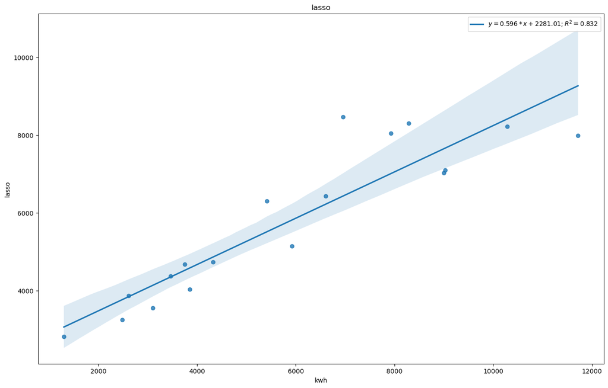

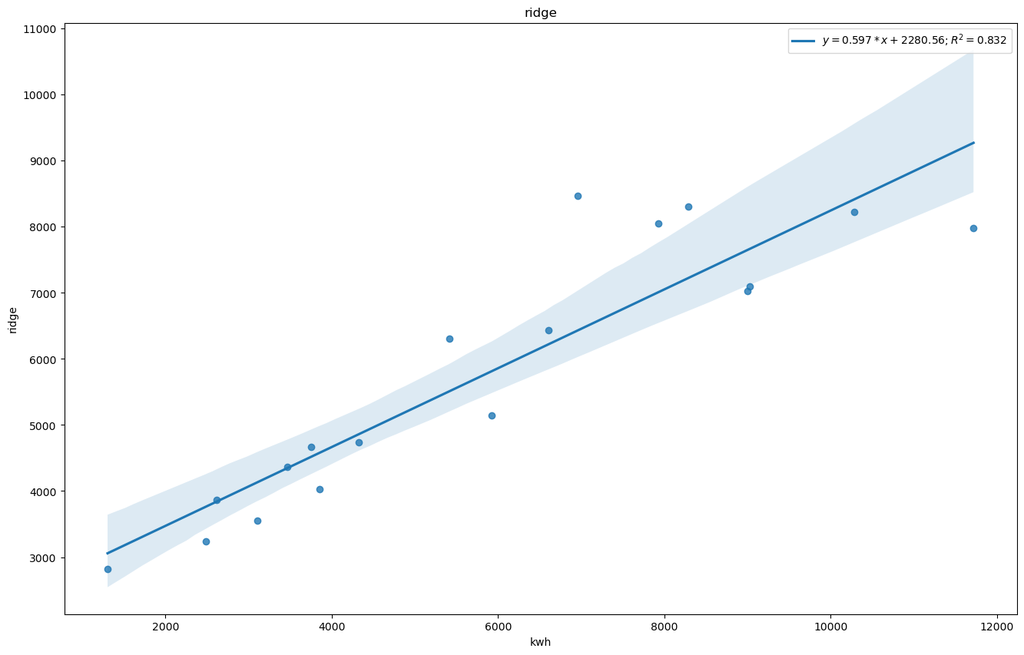

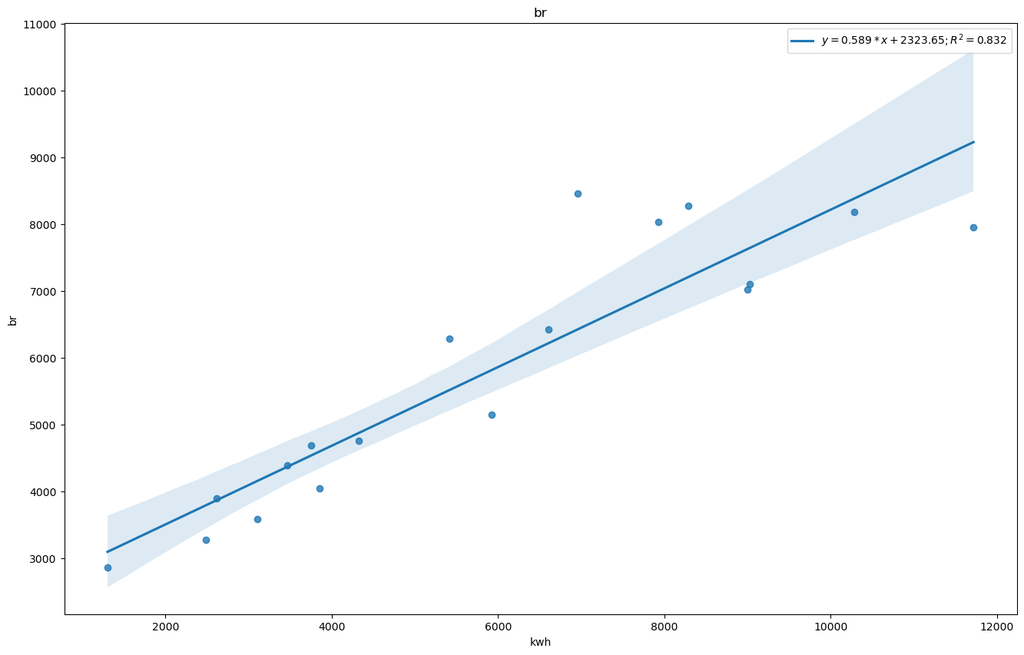

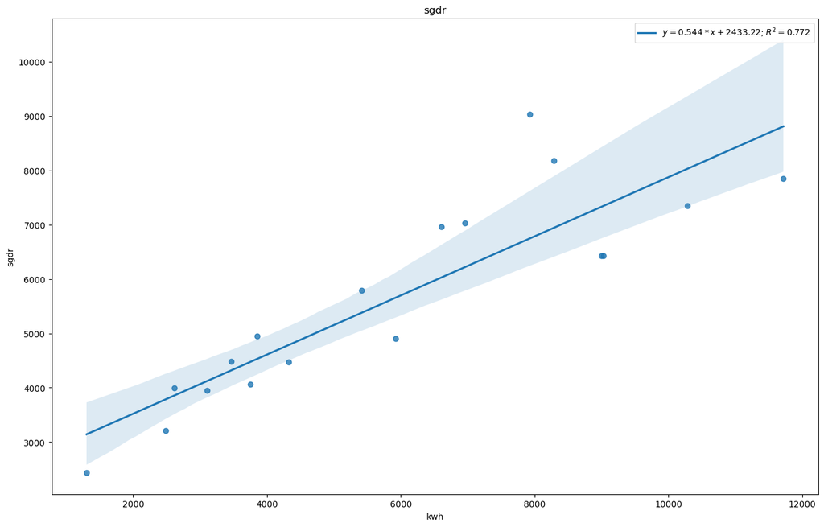

```python
def reg(df, x, y, title=None):
    R2 = round(df[x].corr(df[y]), 2)
    slope, intercept, r_value, pv, se = stats.linregress(df[x], df[y])
    plt.figure(figsize=(16, 10))
    sns.regplot(data=df, x=x, y=y, line_kws={'label': '$y=%3.7s*x+%3.7s; R^2=%3.7s$' % (
        round(slope, 3), round(intercept, 3), round(r_value**2, 3))}).set(title=title)
    plt.legend()
for m in short_list:
    reg(df_test, x='kwh', y=m, title=m)
```

## Ensemble voting regressor

One last trick we can use to make the estimation more robust and potentially better is averaging the predictions of the algorithms hoping that the shortcomings the may have could be made up by the others. The results below don't show significant improvement in performance. Nevertheless, it's worth considering using to make the results more stable.

```python
col_values= [(-gridsearch_results[m]['best_score'], gridsearch_results[m]['test_score']) for m in short_list]
col_values.append((np.nan, mean_absolute_percentage_error(
    test_cp_labels.values, df_test['average_prediction'])))
ind = list(short_list)
ind.append('ensemble_mean')
pd.DataFrame(index=ind, data=col_values,
             columns=['train_score', 'test_score'])
```

|  | train_score | test_score |
| --- | --- | --- |
| lasso | 0.187944 | 0.235230 |
| ridge | 0.187801 | 0.235177 |
| br | 0.189841 | 0.239677 |
| sgdr | 0.183281 | 0.238880 |
| ensemble_mean | NaN | 0.235642 |

## Training on full data set

Finally we can train on the whole data set save the model and get ready for deployment.

```python
# train on full data
all_charge_points = df_initial.drop(columns=['kwh', 'quartiles'])
all_charge_points_labels = df_initial['kwh'].copy()
all_charge_points_quartiles = df_initial['quartiles'].copy()

all_cp_ready = features_pipeline.fit_transform(
    X=all_charge_points, y=all_charge_points_labels)

best_models_retrained = gridsearch_results.copy()

prediction = {}
for m in short_list:
    selected_features = best_models_retrained[m]['selected_features']
    best_models_retrained[m]['best_estimator'] = best_models_retrained[m]['best_estimator'].fit(
        all_cp_ready[:, selected_features], all_charge_points_labels.values)
    predictions = best_models_retrained[m]['best_estimator'].predict(all_cp_ready[:, selected_features])
    best_models_retrained[m]['best_score'] = mean_absolute_percentage_error(
        all_charge_points_labels.values, predictions)
    best_models_retrained[m]['full_pipeline'] = ColumnTransformer(
        [('features_pipeline', features_pipeline), best_models_retrained[m]['best_estimator']])
    prediction[m] = predictions
```

The cell below shows the best scores obtained on the training set when the whole data set is used.

```python
df_train_results = pd.DataFrame.from_dict(prediction)
df_train_results['kwh'] = all_charge_points_labels.values
df_train_results['average_prediction'] = df_train_results[[
    'lasso', 'sgdr', 'ridge', 'br']].mean(axis=1)
# display(df_train_results)
```

```python
col_values= [best_models_retrained[m]['best_score'] for m in short_list]
col_values.append(mean_absolute_percentage_error(
    all_charge_points_labels.values, df_train_results['average_prediction']))
ind = list(short_list)
ind.append('ensemble_mean')
pd.DataFrame(index=ind, data=col_values,
             columns=['train_score'])
```

|  | train_score |
| --- | --- |
| lasso | 0.210007 |
| ridge | 0.209902 |
| br | 0.213540 |
| sgdr | 0.177014 |
| ensemble_mean | 0.198701 |

## Deployment

To deploy the model we would save the object `best_models_retrained` as a pkl and use the key `full_pipeline` to access the complete pipeline that transforms the features and make the predictions.